# Causal ML: Predicting effects

Application notebook

Michael Knaus

02/23

These are the goals of today:

- Hand-code S-learner, T-learner, Causal Forest (at least a little bit), R-learner and DR-learner

# 401(k) dataset again

We again use the data of the `hdm` package. The data was used in [Chernozhukov and Hansen (2004)](https://direct.mit.edu/rest/article/86/3/735/57586/The-Effects-of-401-K-Participation-on-the-Wealth). Their paper investigates the effect of participation in the employer-sponsored 401(k) retirement savings plan (*p401*) on net assets (*net_tfa*). Since then, the data was used to showcase many new methods. It is not the most comprehensive dataset with basically ten covariates/regressors/predictors:

- *age*: age
- *db*: defined benefit pension
- *educ*: education (in years)
- *fsize*: family size
- *hown*: home owner
- *inc*: income (in US $)
- *male*: male
- *marr*: married
- *pira*: participation in individual retirement account (IRA)
- *twoearn*: two earners

However, it is publicly available and the few controls ensure that the programs run not as long as with datasets that you hope to have for your applications.

```r
library(hdm)
library(grf)
library(tidyverse)
library(psych)
# library(devtools)
# install_github("susanathey/causalTree")
library(rpart)
library(rpart.plot)
library(partykit)
library(causalTree)

set.seed(1234) # for replicability

# Get data
data(pension)
# Outcome
Y = pension$net_tfa
# Treatment
W = pension$p401
# Treatment
Z = pension$e401
# Create main effects matrix
X = model.matrix(~ 0 + age + db + educ + fsize + hown + inc + male + marr + pira + twoearn, data = pension)
```

We want to predict effects of 401(k) participation on net assets using the following estimators:

- S-learner (to be defined)
- T-learner
- Causal Tree
- Causal Forest
- R-learner
- DR-learner

# S-learner

We did not discuss it in class, but another straightforward way of getting CATEs is to model $E[Y|W,X]$ and then evaluate it at $E[Y|1,X] - E[Y|0,X]$

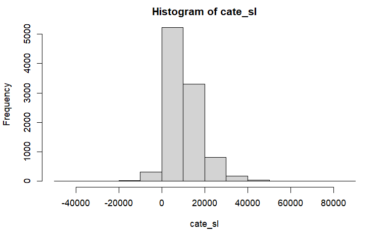

```r
WX = cbind(W,X)
rf = regression_forest(WX,Y)
W0X = cbind(rep(0,length(Y)),X)
W1X = cbind(rep(1,length(Y)),X)
cate_sl = predict(rf,W1X)$predictions - predict(rf,W0X)$predictions
hist(cate_sl)
```

# T-learner

For the T-learner, we implement the following procedure:

1. Use ML estimator of your choice to fit model $\hat{m}(1,X)$ in treated}
2. Use ML estimator of your choice to fit model $\hat{m}(0,X)$ in controls
3. Estimate CATE as $\hat{\tau}(x) = \hat{m}(1,x) - \hat{m}(0,x)$

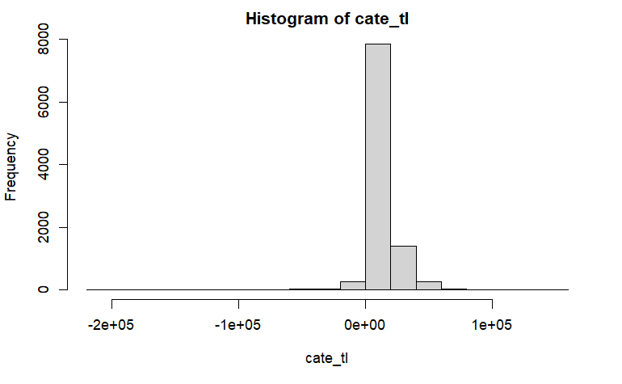

```r
rfm1 = regression_forest(X[W==1,],Y[W==1])
rfm0 = regression_forest(X[W==0,],Y[W==0])
cate_tl = predict(rfm1, X)$predictions - predict(rfm0, X)$predictions
hist(cate_tl)
```

# Causal Tree

Let’s move on with the Causal Tree, which is implemented in the package and function `causalTree`. The package is build for experiments, so we do not control for confounding here. However, if the data were experimental, this is what you would do to implement the method:

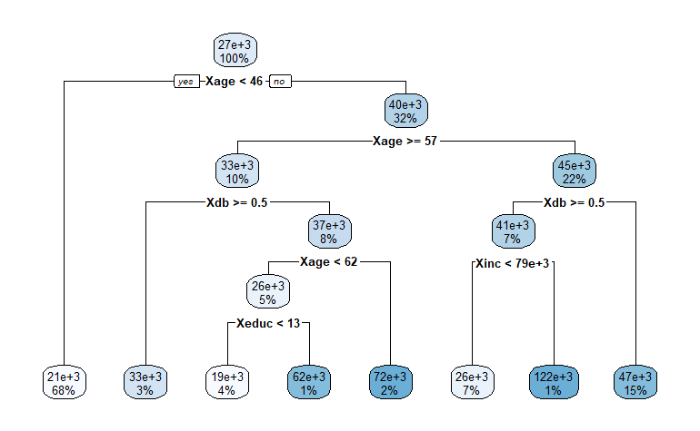

```r
# Prepare data frame
df = data.frame(X,Y)
# Implemented causalTree adapting specification from R example
ctree = causalTree(Y~X, data = df, treatment = W,
                   split.Rule = "CT", cv.option = "CT", split.Honest = T,split.Bucket = F, xval = 5,
                   cp = 0, minsize = 20)
opcp = ctree$cptable[,1][which.min(ctree$cptable[,4])]
opfit = prune(ctree, opcp)
rpart.plot(opfit)
```

However, if we ignore confounding for the sake of the argument, the tree shows substantial heterogeneity regarding age and some other variables.

Given the obvious selection bias, we do not form predictions for causal trees.

# Causal Forest

## `grf` package

Causal Forests are implemented most conveniently with the `causal_forest` function of the `grf` package. If we use the `predict` function for the created object, we get out-of-bag estimated IATEs for every individual in our sample:

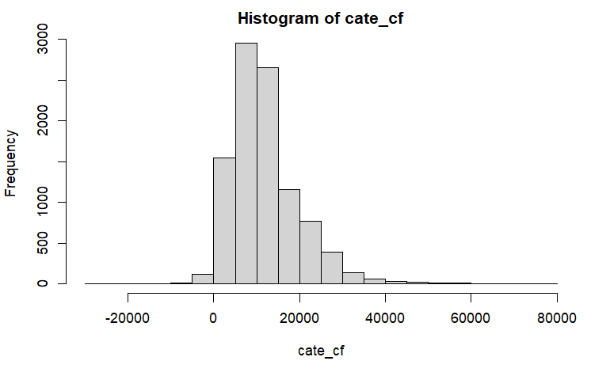

```r
cf = causal_forest(X, Y, W)
cate_cf = predict(cf)$predictions
hist(cate_cf)
```

## Replicated using weighted ROR regression

Now let’s see what the Causal Forest does in the background. To this end, we want to “manually” replicate the predicted effect of individual one. It has a predicted effect of 5292.817192 and has the following characteristics:

```r
X[1,]
```

```
    age      db    educ   fsize    hown     inc    male    marr    pira twoearn
     31       0      12       5       1   28146       0       1       0       0
```

Recall that causal forest estimates CATEs using this formula:
$$\begin{equation}
\hat{\tau}^{cf}(x) = argmin_{\tau} \left\{ \sum_{i=1}^N \alpha_i(x)
\left[(Y_i - \hat{m}(X_i)) - \tau(x)(W_i - \hat{e}(X_i)) \right]^2
\right\},
\end{equation}$$
where $\alpha(x)$ are $x$-specific weights.

We can implement this ourselves this because the causal forest saves all components that were used in the process.

1. We extract the nuisance parameters estimates:

```r
mhat = cf$Y.hat
ehat = cf$W.hat
```

2. We extract the weights using `get_forest_weights`:

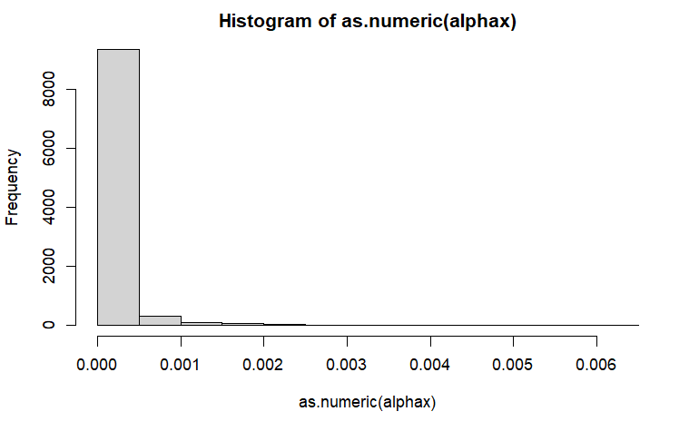

```r
alphax = get_forest_weights(cf)[1,]
hist(as.numeric(alphax))
```

3. We create the residuals and run a weighted residual-on-residual regression (RORR) w/o constant:

```r
Yres = Y - mhat
Wres = W - ehat
manual_cate = lm(Yres ~ 0 + Wres,weights = as.numeric(alphax))$coefficients
manual_cate
```

```
    Wres
5306.271
```

Let’s check whether this is equal to the `causal_forest` prediction:

```r
all.equal(as.numeric(cate_cf[1]),as.numeric(manual_cate))
```

```
[1] "Mean relative difference: 0.002541852"
```

Nope :-(

What did we miss?

The `causal_forest` runs the weighted RORR with constant. This constant should asymptotically be zero, but in finite samples it is not:

```r
Yres = Y - mhat
Wres = W - ehat
manual_cate_const = lm(Yres ~ Wres,weights = as.numeric(alphax))
summary(manual_cate_const)
```

```
Call:
lm(formula = Yres ~ Wres, weights = as.numeric(alphax))

Weighted Residuals:
   Min     1Q Median     3Q    Max
 -4662      0      0      0   3353

Coefficients:
            Estimate Std. Error t value Pr(>|t|)
(Intercept)   -604.9      187.4  -3.228  0.00126 **
Wres          5292.8      479.2  11.046  < 2e-16 ***
---
Signif. codes:  0 ‘***’ 0.001 ‘**’ 0.01 ‘*’ 0.05 ‘.’ 0.1 ‘ ’ 1

Residual standard error: 187.4 on 3151 degrees of freedom
Multiple R-squared:  0.03728,   Adjusted R-squared:  0.03697
F-statistic:   122 on 1 and 3151 DF,  p-value: < 2.2e-16
```

With constant the results from the package and our “manually” coded version coincide:

```r
all.equal(as.numeric(cate_cf[1]),as.numeric(manual_cate_const$coefficients[2]))
```

```
[1] TRUE
```

After all, it boils down to run OLS.

# R-learner

## Hand-coded using modified covariates

To illustrate how we can implement the R-leaner like this for assuming a linear CATE model
$$\begin{equation}
\hat{\beta}^{rl} = argmin_{\beta} \sum_{i=1}^N \big(Y_i - \hat{m}(X_i)
- X_i^* \beta \big)^2
\end{equation}$$
we recycle the nuisance parameters of above and just need to define the modified/pseudo-covariates $X^* = X(W - \hat{e}(X))$

```r
# Create residuals
res_y = Y-mhat
res_w = W-ehat

# Modify covariates (multiply each column including constant with residual)
n = length(Y)
X_wc = cbind(rep(1,n),X)
Xstar = X_wc * res_w
# Regress outcome residual on modified covariates
rl_ols = lm(res_y ~ 0 + Xstar)
summary(rl_ols)
```

```
Call:
lm(formula = res_y ~ 0 + Xstar)

Residuals:
    Min      1Q  Median      3Q     Max
-507194  -10540   -1235    2272 1439820

Coefficients:
               Estimate Std. Error t value Pr(>|t|)
Xstar        -1.614e+04  1.081e+04  -1.493   0.1354
Xstarage      3.173e+02  1.469e+02   2.160   0.0308 *
Xstardb       5.268e+03  2.904e+03   1.814   0.0697 .
Xstareduc     4.398e+02  5.561e+02   0.791   0.4291
Xstarfsize   -8.555e+01  1.098e+03  -0.078   0.9379
Xstarhown     6.090e+03  3.259e+03   1.868   0.0617 .
Xstarinc      6.168e-02  6.567e-02   0.939   0.3476
Xstarmale     5.816e+03  3.631e+03   1.602   0.1092
Xstarmarr     3.476e+03  4.600e+03   0.756   0.4499
Xstarpira    -9.279e+02  3.128e+03  -0.297   0.7667
Xstartwoearn -2.412e+03  3.658e+03  -0.659   0.5097
---
Signif. codes:  0 ‘***’ 0.001 ‘**’ 0.01 ‘*’ 0.05 ‘.’ 0.1 ‘ ’ 1

Residual standard error: 53830 on 9904 degrees of freedom
Multiple R-squared:  0.01336,   Adjusted R-squared:  0.01226
F-statistic: 12.19 on 11 and 9904 DF,  p-value: < 2.2e-16
```

Now we need to take the coefficients of this model to get fitted values of the CATEs as $X \beta$

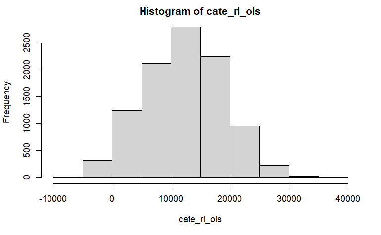

```r
cate_rl_ols = X_wc %*% rl_ols$coefficients
hist(cate_rl_ols)
```

## Hand-coded using pseudo-outcomes and weights

The more generic alternative is to use the unmodified covariates in a weighted regression with pseudo outcomes:
$$\hat{\tau}^{rl}(x) = argmin_{\tau} \sum_{i=1}^N
\underbrace{(W_i - \hat{e}(X_i))^2}_{\text{weight}}
\left(\underbrace{\frac{Y_i - \hat{m}(X_i)}{W_i -
\hat{e}(X_i)}}_{\text{pseudo-outcome}} - X_i\beta
\right)^2$$

For the sake of the argument run it again with OLS

```r
# Create pseudo-outcome (outcome res divided by treatment res)
pseudo_rl = res_y / res_w

# Create weights
weights_rl = res_w^2

# Weighted regression of pseudo-outcome on covariates
rols_fit = lm(pseudo_rl ~ X, weights=weights_rl)
summary(rols_fit)
```

```
Call:
lm(formula = pseudo_rl ~ X, weights = weights_rl)

Weighted Residuals:
     Min       1Q   Median       3Q      Max
-1217226    -6108      -72     6672  1439820

Coefficients:
              Estimate Std. Error t value Pr(>|t|)
(Intercept) -1.614e+04  1.081e+04  -1.493   0.1354
Xage         3.173e+02  1.469e+02   2.160   0.0308 *
Xdb          5.268e+03  2.904e+03   1.814   0.0697 .
Xeduc        4.398e+02  5.561e+02   0.791   0.4291
Xfsize      -8.555e+01  1.098e+03  -0.078   0.9379
Xhown        6.090e+03  3.259e+03   1.868   0.0617 .
Xinc         6.168e-02  6.567e-02   0.939   0.3476
Xmale        5.816e+03  3.631e+03   1.602   0.1092
Xmarr        3.476e+03  4.600e+03   0.756   0.4499
Xpira       -9.279e+02  3.128e+03  -0.297   0.7667
Xtwoearn    -2.412e+03  3.658e+03  -0.659   0.5097
---
Signif. codes:  0 ‘***’ 0.001 ‘**’ 0.01 ‘*’ 0.05 ‘.’ 0.1 ‘ ’ 1

Residual standard error: 53830 on 9904 degrees of freedom
Multiple R-squared:  0.00233,   Adjusted R-squared:  0.001322
F-statistic: 2.313 on 10 and 9904 DF,  p-value: 0.01034
```

# DR-learner

Finally, run the DR-learner that creates the pseudo-outcome in a first step
$$\begin{align}
\tilde{Y}_{ATE} = \underbrace{\hat{m}(1,X) -
\hat{m}(0,X)}_{\text{outcome predictions}} + \underbrace{\frac{W (Y -
\hat{m}(1,X))}{\hat{e}(X)} - \frac{(1-W) (Y -
\hat{m}(0,X))}{1-\hat{e}(X)}}_{\text{weighted residuals}} \nonumber
\end{align}$$

and uses it in a final regression step.

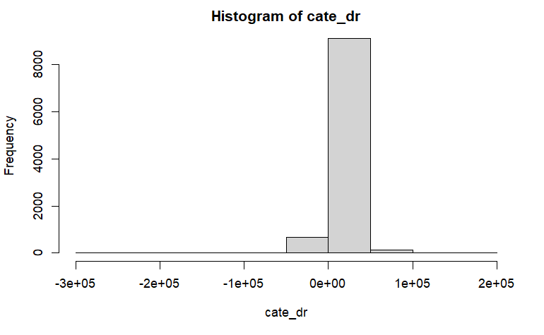

```r
nfolds = 5
fold = sample(1:nfolds,n,replace=T)
mwhat0 = mwhat1 = rep(NA,n)

for (i in 1:nfolds){
  rfm0 = regression_forest(X[fold != i & W==0,],Y[fold != i & W==0])
  mwhat0[fold == i] = predict(rfm0, X[fold == i,])$predictions

  rfm1 = regression_forest(X[fold != i & W==1,],Y[fold != i & W==1])
  mwhat1[fold == i] = predict(rfm1, X[fold == i,])$predictions
}

Y_tilde = mwhat1 - mwhat0 + W * (Y - mwhat1) / ehat - (1 - W) * (Y - mwhat0) / (1-ehat)

cate_dr = predict(regression_forest(X,Y_tilde))$predictions
hist(cate_dr)
```

Plot the results against each other to see that they are correlated, but far from finding the same predictions.

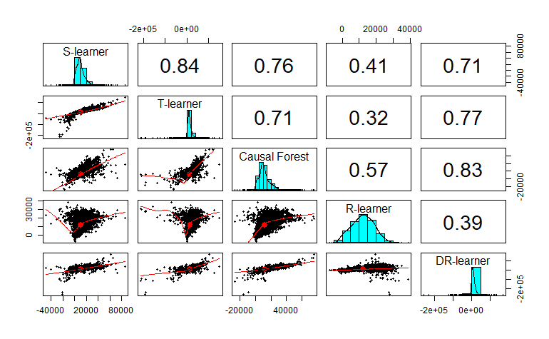

```r
# Store and plot predictions
results = cbind(cate_sl,cate_tl,cate_cf,cate_rl_ols,cate_dr)
colnames(results) = c("S-learner","T-learner","Causal Forest","R-learner","DR-learner")
pairs.panels(results,method = "pearson")
```

```r
describe(results)
```

|  | vars | n | mean | sd | median | trimmed | mad | min | max | range | skew | kurtosis | se |
| --- | --- | --- | --- | --- | --- | --- | --- | --- | --- | --- | --- | --- | --- |
| S-learner | 1 | 9915 | 10238.61 | 8038.33 | 9096.36 | 9506.27 | 6266.57 | -47822.03 | 85093.89 | 132915.9 | 1.19 | 5.27 | 80.73 |
| T-learner | 2 | 9915 | 12268.30 | 13569.83 | 10237.17 | 11222.27 | 7475.52 | -213364.31 | 148918.34 | 362282.7 | -1.78 | 43.13 | 136.28 |
| Causal Forest | 3 | 9915 | 11957.57 | 8182.52 | 10439.26 | 11136.16 | 5826.10 | -26169.58 | 75284.99 | 101454.6 | 1.42 | 4.43 | 82.18 |
| R-learner | 4 | 9915 | 12199.46 | 6690.57 | 12326.16 | 12193.88 | 7096.10 | -7473.19 | 38964.11 | 46437.3 | 0.03 | -0.43 | 67.19 |
| DR-learner | 5 | 9915 | 11585.69 | 13034.77 | 9662.48 | 10464.21 | 8759.52 | -256764.97 | 169466.72 | 426231.7 | -0.98 | 44.66 | 130.91 |